# Getting Started with EpiRomics

Authors: Alex M. Mawla & Mark O. Huising. Copyright 2020 - Present.

2021-09-28

# Abstract

**Summary** epiRomics is an R package designed to integrate multi-omics data in order to identify and visualize enhancer regions alongside gene expression and other epigenomic modifications. Regulatory network analysis can be done using combinatory approaches to infer regions of significance such as enhancers, when combining ChIP and histone data. Downstream analysis can identify co-occurrence of these regions of interest with other user-supplied data, such as chromatin availability or gene expression. Finally, this package allows for results to be visualized at high resolution in a stand-alone browser.

**Availability and Implementation** epiRomics is released under Artistic-2.0 License. The source code and documents are freely available through Github (https://github.com/Huising-Lab/epiRomics).

**Contact** ammawl@ucdavis.edu or mhuising@ucdavis.edu

**Supplementary information** Supplementary data, and methods are available online on *biorXiv* or *Github.*

**Competing Interest Statement**

The authors have declared no competing interest.

# Citation

If you use epiRomics in published research, please cite:

Mawla, AM& Huising, MO. **epiRomics: a multi-omics R package to identify and visualize enhancers.**

biorXiv 2021. doi:https://doi.org/10.1101/2021.08.19.456732

# Loading the epiRomics package and dependencies for vignette

```r
## loading packages

library(epiRomics)

library(TxDb.Hsapiens.UCSC.hg38.knownGene)

library(org.Hs.eg.db)
```

# Brief explanation of example data

This package includes some example data to get you started, delineating human pancreatic islet enhancers between alpha and beta cells.

Human pancreatic islet alpha and beta ATAC- and companion RNA- Seq data were retrieved from GEO accession GSE76268 (Ackermann, et al., 2016).

ATAC samples were processed using the ENCODE-DCC ATAC sequencing pipeline, aligning to the hg38 (Harrow, et al., 2012) build of the human genome (Consortium, 2012; Davis, et al., 2018).

Peak calls generated through the pipeline using MACS2 (Zhang, et al., 2008) were analyzed downstream through the BioConductor package DiffBind (Ross-Innes, et al., 2012) in order to identify differentially enriched chromatin regions between the two cell types.

RNA samples were quality controlled using the tool fastp (Chen, et al., 2018), and aligned using STAR (Dobin, et al., 2013) to the hg38 build of the human genome. Wiggle files produced by the STAR aligner were then merged by cell type using UCSC command line tools.

Bigwigs merged by cell type were subsetted to chromosome 1 using UCSC command line tools (Kent, et al., 2010).

ChIP-sequencing peak calls generated using MACS2 for human pancreatic islet transcription factors Foxa2, MafB, Nkx2.2, Nkx6.1, and Pdx1 were retrieved from the EMBL-EBI repository database E-MTAB-1919 (Pasquali, et al., 2014). All peak calls were lifted over to the hg38 genome build using the UCSC genome browser liftOver tool (Kent, et al., 2002).

Histone-sequencing peak calls generated using MACS2 for histones H3k27ac and H3k4me1 were retrieved from GEO accession GSE16256 (Bernstein, et al., 2010), and for histone H2A.Z from the EMBL-EBI repository database E-MTAB-1919 (Pasquali, et al., 2014). All peak calls were lifted over to the hg38 genome build using the UCSC genome browser liftOver tool.

The FANTOM5 human enhancer database (Lizio, et al., 2015) was retrieved, and all regions were lifted over to the hg38 genome build using the UCSC genome browser liftOver tool.

Human ultra-conserved non-coding elements (UCNEs) were retrieved form the UCNE database (Dimitrieva and Bucher, 2012), and all regions were lifted over to the hg38 genome build using the UCSC genome browser liftOver tool.

The human islet regulome database was retrieved (Miguel-Escalada, et al., 2019) and all regions were lifted over to the hg38 genome build using the UCSC genome browser liftOver tool.

Lets load and take a look at how to properly format the datasets epiRomics uses to build the initial database.

```r
## Required columns are: name, path, genome, format, and type

## The genome must also be in proper format, e.g. mm10 or hg38

## Type of data can be histone, methyl, SNP, or ChIP. ChIP is
## required for some downstream functions to work appropriately.

example_epiRomics_Db_sheet <- read.csv(file = system.file("extdata", "example_epiRomics_Db_sheet_user_paths.csv",
    package = "epiRomics"))

head(example_epiRomics_Db_sheet)
```

|  | name | path | genome | format | type |
| --- | --- | --- | --- | --- | --- |
| 1 | h3k27ac | /Library/Frameworks/R.framework/Versions/4.1/Resources/library/epiRomics/extdata/Histone/H3k27ac_hg38.bed | hg38 | bed | histone |
| 2 | h3k4me1 | /Library/Frameworks/R.framework/Versions/4.1/Resources/library/epiRomics/extdata/Histone/H3K4me1_hg38.bed | hg38 | bed | histone |
| 3 | foxa2 | /Library/Frameworks/R.framework/Versions/4.1/Resources/library/epiRomics/extdata/ChIP/FOXA2_hg38.bed | hg38 | bed | chip |
| 4 | mafb | /Library/Frameworks/R.framework/Versions/4.1/Resources/library/epiRomics/extdata/ChIP/MAFB_hg38.bed | hg38 | bed | chip |
| 5 | nkx2_2 | /Library/Frameworks/R.framework/Versions/4.1/Resources/library/epiRomics/extdata/ChIP/NKX2_2_hg38.bed | hg38 | bed | chip |
| 6 | nxk6_1 | /Library/Frameworks/R.framework/Versions/4.1/Resources/library/epiRomics/extdata/ChIP/NKX6_1_hg38.bed | hg38 | bed | chip |

# How to load and build the database

```r
## epiRomics_build_dB constructs a database of class epiRomics with this data sheet

epiRomics_dB <- epiRomics_build_dB(epiRomics_db_file = system.file("extdata", "example_epiRomics_Db_sheet_user_paths.csv",
    package = "epiRomics"), txdb_organism = "TxDb.Hsapiens.UCSC.hg38.knownGene::TxDb.Hsapiens.UCSC.hg38.knownGene",
    epiRomics_genome = "hg38", epiRomics_organism = "org.Hs.eg.db")
```

```
#> Building enhancers...
#> snapshotDate(): 2021-05-18
#> loading from cache
#> Building promoters...
#> Building 1to5kb upstream of TSS...
#> Building intergenic...
#> Building cds...
#> Building 5UTRs...
#> Building 3UTRs...
#> Building exons...
#> Building first exons...
#> Building introns...
#> Building intron exon boundaries...
#> Building exon intron boundaries...
#> Building CpG islands...
#> Building CpG shores...
#> Building CpG shelves...
#> Building inter-CpG-islands...
#> snapshotDate(): 2021-05-18
#> Building lncRNA transcripts...
#> loading from cache
```

# Delineating active enhancers using H3k4me1 and H3k27ac marks as a proxy

```r
## Identifying active, putative enhancers

# 3 There is a lot of flexibility for data exploration here. In this
# example, we search for putative enhancers using two histone marks
# known to co-occur at enhancer regions - h3k4me1 & h3k27ac

epiRomics_putative_enhancers <- epiRomics_enhancers(epiRomics_dB, epiRomics_histone_mark_1 = "h3k4me1",
    epiRomics_histone_mark_2 = "h3k27ac")

## Taking a look, we see a list of 19,692 putative enhancers demarked
## by H3k4me1 & H3k27ac

epiRomics_putative_enhancers@annotations
```

```
#> GRanges object with 19692 ranges and 0 metadata columns:
#>           seqnames            ranges strand
#>              <Rle>         <IRanges>  <Rle>
#>       [1]     chr1    999886-1000011      *
#>       [2]     chr1   1000228-1000811      *
#>       [3]     chr1   1000850-1001468      *
#>       [4]     chr1   1005007-1006023      *
#>       [5]     chr1   1013701-1013893      *
#>       ...      ...               ...    ...
#>   [19688]     chrY 12392544-12392994      *
#>   [19689]     chrY 13282680-13282760      *
#>   [19690]     chrY 15455449-15455788      *
#>   [19691]     chrY 19066496-19066508      *
#>   [19692]     chrY 19075542-19075899      *
#>   -------
#>   seqinfo: 595 sequences (1 circular) from hg38 genome
```

# Cross-referencing enhancer calls to other databases

## FANTOM Enhancer Database

```r
## Now we have a list of regions as possible candidates for
## enhancers, but where do we go from here? One way to increase
## confidence of these calls is to cross this list against an
## enhancer database, for instance, FANTOM.

## NOTE: This option may not be available for all organisms.

epiRomics_putative_enhancers_filtered_fantom <- epiRomics_enhancers_filter(epiRomics_putative_enhancers,
    epiRomics_dB, epiRomics_type = "hg38_custom_fantom")

## Taking a look, we see a reduced number of 2,749 candidate regions

epiRomics_putative_enhancers_filtered_fantom@annotations
```

```
#> GRanges object with 2749 ranges and 0 metadata columns:
#>          seqnames              ranges strand
#>             <Rle>           <IRanges>  <Rle>
#>      [1]     chr1     1021242-1021277      *
#>      [2]     chr1     1021318-1021698      *
#>      [3]     chr1     1079632-1080061      *
#>      [4]     chr1     1080101-1080628      *
#>      [5]     chr1     1128200-1128445      *
#>      ...      ...                 ...    ...
#>   [2745]     chrX 154369950-154370183      *
#>   [2746]     chrX 154371971-154372237      *
#>   [2747]     chrX 154372350-154372695      *
#>   [2748]     chrX 154517139-154517596      *
#>   [2749]     chrX 154734550-154734738      *
#>   -------
#>   seqinfo: 595 sequences (1 circular) from hg38 genome
```

## Human Pancreatic Islet Regulome Enhancer Database

```r
## We can also filter putative enhancer calls against active
## enhancers from the human islet regulome database

epiRomics_putative_enhancers_filtered_regulome_active <- epiRomics_enhancers_filter(epiRomics_putative_enhancers,
    epiRomics_dB, epiRomics_type = "hg38_custom_regulome_active")


epiRomics_putative_enhancers_filtered_regulome_active@annotations
```

```
#> GRanges object with 6025 ranges and 0 metadata columns:
#>          seqnames              ranges strand
#>             <Rle>           <IRanges>  <Rle>
#>      [1]     chr1     1068896-1068951      *
#>      [2]     chr1     1069171-1069333      *
#>      [3]     chr1     1079632-1080061      *
#>      [4]     chr1     1080101-1080628      *
#>      [5]     chr1     1158358-1158930      *
#>      ...      ...                 ...    ...
#>   [6021]     chrX 153381411-153381523      *
#>   [6022]     chrX 153381677-153381956      *
#>   [6023]     chrX 153382322-153382448      *
#>   [6024]     chrX 153985442-153985689      *
#>   [6025]     chrX 154091801-154091996      *
#>   -------
#>   seqinfo: 595 sequences (1 circular) from hg38 genome
```

## Human Pancreatic Islet Regulome Super-Enhancer Database

```r
## We can also filter putative enhancer calls against super enhancers
## from human islet regulome database

epiRomics_putative_enhancers_filtered_regulome_super <- epiRomics_enhancers_filter(epiRomics_putative_enhancers,
    epiRomics_dB, epiRomics_type = "hg38_custom_regulome_super")

epiRomics_putative_enhancers_filtered_regulome_super@annotations
```

```
#> GRanges object with 2401 ranges and 0 metadata columns:
#>          seqnames            ranges strand
#>             <Rle>         <IRanges>  <Rle>
#>      [1]     chr1   7574092-7574479      *
#>      [2]     chr1   7574640-7575094      *
#>      [3]     chr1   8169274-8169689      *
#>      [4]     chr1   8170112-8170857      *
#>      [5]     chr1   8174089-8174358      *
#>      ...      ...               ...    ...
#>   [2397]    chr22 46109916-46110442      *
#>   [2398]    chr22 46115774-46116154      *
#>   [2399]    chr22 46116326-46116501      *
#>   [2400]     chrX 39813348-39813627      *
#>   [2401]     chrX 39814304-39814607      *
#>   -------
#>   seqinfo: 595 sequences (1 circular) from hg38 genome
```

## Human Ultra-Conserved Non-Coding Elements Database

```r
## We can also filter putative enhancer calls against Ultra-Conserved
## Non-Coding Elements

epiRomics_putative_enhancers_filtered_ucnes <- epiRomics_enhancers_filter(epiRomics_putative_enhancers,
    epiRomics_dB, epiRomics_type = "hg38_custom_ucnes")


epiRomics_putative_enhancers_filtered_ucnes@annotations
```

```
#> GRanges object with 11 ranges and 0 metadata columns:
#>        seqnames              ranges strand
#>           <Rle>           <IRanges>  <Rle>
#>    [1]     chr1 164635220-164635921      *
#>    [2]     chr1 164711914-164712296      *
#>    [3]     chr1 164712350-164713071      *
#>    [4]     chr1 200079185-200079426      *
#>    [5]     chr1 213585694-213586385      *
#>    [6]     chr3   71131859-71132164      *
#>    [7]     chr9 106921420-106921764      *
#>    [8]    chr11 114163425-114164860      *
#>    [9]    chr15   36903894-36904085      *
#>   [10]    chr15   53447393-53447809      *
#>   [11]    chr21   16534340-16534665      *
#>   -------
#>   seqinfo: 595 sequences (1 circular) from hg38 genome
```

# Screening for high transcription factor co-binding sites

Biology has established that enhancers can be quite redundant, and not all play an active role in regulating a cell’s activity. How can we utilize other epigenomic data in order to identify true enhanceosome regions? One way is to cross this list against all ChIP data of the cell type. A true enhanceosome region should have made it through our filtering thus far, and contain several binding sites for known TFs. Co-binding is expected, and the list is sorted by the highest number of ChIP hits within the region.

```r
epiRomics_putative_enhanceosome_fantom <- epiRomics_enhanceosome(epiRomics_putative_enhancers_filtered_fantom,
    epiRomics_dB)
```

```
#>
#> >> preparing features information...      2021-09-28 19:08:08
#> >> identifying nearest features...        2021-09-28 19:08:19
#> >> calculating distance from peak to TSS...   2021-09-28 19:08:21
#> >> assigning genomic annotation...        2021-09-28 19:08:21
#> >> adding gene annotation...          2021-09-28 19:09:11
#> >> assigning chromosome lengths           2021-09-28 19:09:12
#> >> done...                    2021-09-28 19:09:12
## Taking a look, we see the top candidates meet the criteria we list
## as expected
```

```r
epiRomics_putative_enhanceosome_fantom@annotations
```

```
#> GRanges object with 2749 ranges and 19 metadata columns:
#>        seqnames              ranges strand |     foxa2      mafb    nkx2_2
#>           <Rle>           <IRanges>  <Rle> | <integer> <integer> <integer>
#>    183     chr1 154418514-154419684      * |         2         2         1
#>   1096     chr9     2242369-2242873      * |         2         1         1
#>   2615    chr22   30310745-30311570      * |         2         1         2
#>     34     chr1   10685395-10688670      * |         1         0         1
#>    792     chr6   30748438-30749427      * |         2         1         1
#>    ...      ...                 ...    ... .       ...       ...       ...
#>   2743     chrX 153927339-153927701      * |         0         0         0
#>   2745     chrX 154369950-154370183      * |         0         0         0
#>   2746     chrX 154371971-154372237      * |         0         0         0
#>   2747     chrX 154372350-154372695      * |         0         0         0
#>   2748     chrX 154517139-154517596      * |         0         0         0
#>           nxk6_1      pdx1      h2az ChIP_Hits             annotation   geneChr
```

[output cut: 41 more lines]

```r
head(as.data.frame(epiRomics_putative_enhanceosome_fantom@annotations)[as.data.frame(epiRomics_putative_enhanceosome_fantom@annotations)$seqnames ==
    "chr1", ])
```

|  | seqnames | start | end | width | strand | foxa2 | mafb | nkx2_2 | nxk6_1 | pdx1 | h2az | ChIP_Hits | annotation | geneChr | geneStart | geneEnd | geneLength | geneStrand | geneId | transcriptId | distanceToTSS | ENSEMBL | SYMBOL | GENENAME |
| --- | --- | --- | --- | --- | --- | --- | --- | --- | --- | --- | --- | --- | --- | --- | --- | --- | --- | --- | --- | --- | --- | --- | --- | --- |
| 183 | chr1 | 154418514 | 154419684 | 1171 | * | 2 | 2 | 1 | 2 | 1 | 2 | 10 | Intron (ENST00000622330.4/3570, intron 1 of 6) | 1 | 154429343 | 154449979 | 20637 | 1 | 3570 | ENST00000476006.5 | -9659 | ENSG00000160712 | IL6R | interleukin 6 receptor |
| 34 | chr1 | 10685395 | 10688670 | 3276 | * | 1 | 0 | 1 | 1 | 2 | 2 | 7 | Intron (ENST00000377022.8/54897, intron 4 of 20) | 1 | 10660737 | 10693912 | 33176 | 2 | 54897 | ENST00000478728.2 | 5242 | ENSG00000130940 | CASZ1 | castor zinc finger 1 |
| 24 | chr1 | 8170112 | 8170857 | 746 | * | 1 | 1 | 1 | 1 | 1 | 1 | 6 | Distal Intergenic | 1 | 8201518 | 8215207 | 13690 | 1 | 102724539 | ENST00000670361.1 | -30661 | ENSG00000227634 | LINC01714 | long intergenic non-protein coding RNA 1714 |
| 67 | chr1 | 21638834 | 21639978 | 1145 | * | 1 | 1 | 1 | 1 | 1 | 1 | 6 | Intron (ENST00000290101.8/5909, intron 2 of 26) | 1 | 21596221 | 21651820 | 55600 | 2 | 5909 | ENST00000471600.6 | 11842 | ENSG00000076864 | RAP1GAP | RAP1 GTPase activating protein |
| 71 | chr1 | 22414515 | 22414806 | 292 | * | 1 | 1 | 1 | 1 | 1 | 1 | 6 | Distal Intergenic | 1 | 22428838 | 22511763 | 82926 | 1 | 9923 | ENST00000650433.1 | -14032 | ENSG00000184677 | ZBTB40 | zinc finger and BTB domain containing 40 |
| 256 | chr1 | 205318810 | 205319660 | 851 | * | 1 | 1 | 2 | 1 | 0 | 1 | 6 | Promoter (2-3kb) | 1 | 205302063 | 205321745 | 19683 | 2 | 81788 | ENST00000367157.6 | 2085 | ENSG00000163545 | NUAK2 | NUAK family kinase 2 |

```r
## Find Index
which(names(epiRomics_putative_enhanceosome_fantom@annotations) == 183)
```

```
#> [1] 1
```

# Transcription factor decision trees

ChIP dataset repositories are quite sizeable for many organisms and cell types, with the expectation to only grow larger. Many different TFs binding to a putative enhancer region may not be that meaningful in the context of your biological question. A further step would be to ask whether there are co-TFs that pop up together, and whether this pattern varies across the functional annotation of the genome, i.e. does the combination of two TFs on enhanceosomes change on the gene body compared to distal intergenic regions?

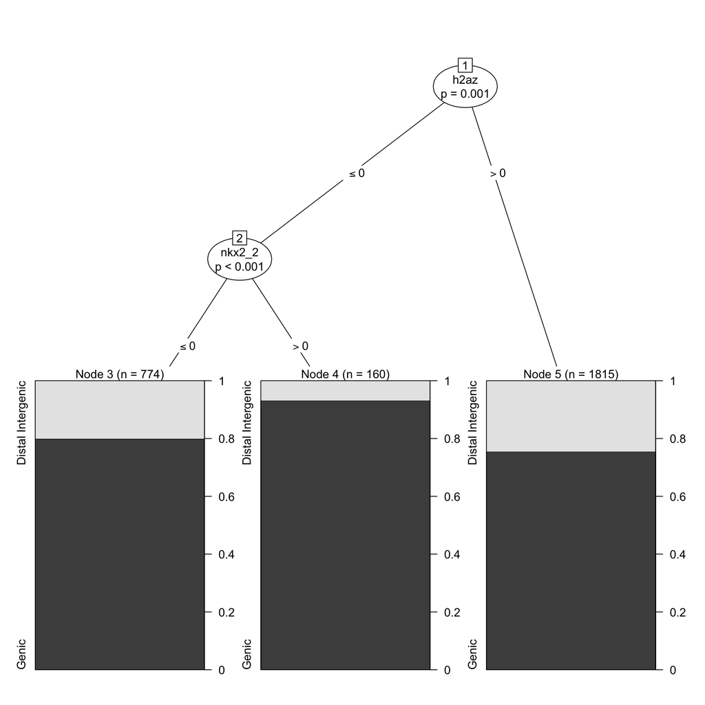

```r
plot(epiRomics_predictors(epiRomics_putative_enhanceosome_fantom))
```

# Intersecting and visualizing ATAC- and RNA-Seq data

What if you wanted to visualize co-binding on your FANTOM filtered putative enhancer region? And do you have additional data you want to include for visualization, such as ATAC and RNA Seq? Lets take a look at one of the top hits

```r
## Read in ATAC Seq and RNA Seq track bigwigs

## NOTE: These bigwigs are subsetted to chromosome 1. Indices not
## falling on chromosome 1 will return an error.

epiRomics_track_connection <- read.csv(system.file("extdata", "example_epiRomics_BW_sheet_user_paths.csv",
    package = "epiRomics"))
```

```r
epiRomics_track_layer_human(
  epiRomics_putative_enhanceosome_fantom,
  epiRomics_index = which(
    names(epiRomics_putative_enhanceosome_fantom@annotations) == 183
  ),
  epiRomics_dB = epiRomics_dB,
  epiRomics_track_connection = epiRomics_track_connection
)
```

```
#> [1] "not empty"
#> [1] 103.678
#> [1] "not empty"
#> [1] 77.5726
#> [1] "not empty"
#> [1] 33.2945
#> [1] "not empty"
#> [1] 50.4959
```

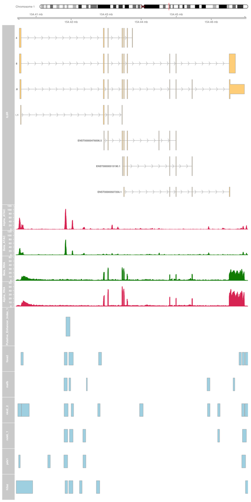

```r
## What about a region that overlapped with active enhancers from the
## human islet regulome database?

epiRomics_putative_enhanceosome_regulome_active <- epiRomics_enhanceosome(epiRomics_putative_enhancers_filtered_regulome_active,
    epiRomics_dB)
```

```
#> >> preparing features information...      2021-09-28 19:11:33
#> >> identifying nearest features...        2021-09-28 19:11:33
#> >> calculating distance from peak to TSS...   2021-09-28 19:11:34
#> >> assigning genomic annotation...        2021-09-28 19:11:34
#> >> adding gene annotation...          2021-09-28 19:11:42
#> >> assigning chromosome lengths           2021-09-28 19:11:42
#> >> done...                    2021-09-28 19:11:42
```

```r
epiRomics_putative_enhanceosome_regulome_active@annotations
```

```
#> GRanges object with 6025 ranges and 19 metadata columns:
#>        seqnames              ranges strand |     foxa2      mafb    nkx2_2
#>           <Rle>           <IRanges>  <Rle> | <integer> <integer> <integer>
#>    456     chr1 154418514-154419684      * |         2         2         1
#>   2082     chr7     1555599-1556082      * |         1         1         1
#>   2572     chr9     2242369-2242873      * |         2         1         1
#>   3421    chr11   65416576-65419753      * |         1         1         2
#>   4709    chr17     7887867-7889135      * |         1         0         2
#>    ...      ...                 ...    ... .       ...       ...       ...
#>   5999     chrX            49184194      * |         0         0         0
#>   6001     chrX   70478965-70479351      * |         0         0         0
#>   6006     chrX 107710676-107711066      * |         0         0         0
#>   6007     chrX 107711430-107711673      * |         0         0         0
#>   6020     chrX 150874055-150874330      * |         0         0         0
#>           nxk6_1      pdx1      h2az ChIP_Hits             annotation   geneChr
```

[output cut: 41 more lines]

```r
head(as.data.frame(epiRomics_putative_enhanceosome_regulome_active@annotations)[as.data.frame(epiRomics_putative_enhanceosome_regulome_active@annotations)$seqnames ==
    "chr1", ])
```

|  | seqnames | start | end | width | strand | foxa2 | mafb | nkx2_2 | nxk6_1 | pdx1 | h2az | ChIP_Hits | annotation | geneChr | geneStart | geneEnd | geneLength | geneStrand | geneId | transcriptId | distanceToTSS | ENSEMBL | SYMBOL | GENENAME |
| --- | --- | --- | --- | --- | --- | --- | --- | --- | --- | --- | --- | --- | --- | --- | --- | --- | --- | --- | --- | --- | --- | --- | --- | --- |
| 456 | chr1 | 154418514 | 154419684 | 1171 | * | 2 | 2 | 1 | 2 | 1 | 2 | 10 | Intron (ENST00000622330.4/3570, intron 1 of 6) | 1 | 154429343 | 154449979 | 20637 | 1 | 3570 | ENST00000476006.5 | -9659 | ENSG00000160712 | IL6R | interleukin 6 receptor |
| 82 | chr1 | 10685395 | 10688670 | 3276 | * | 1 | 0 | 1 | 1 | 2 | 2 | 7 | Intron (ENST00000377022.8/54897, intron 4 of 20) | 1 | 10660737 | 10693912 | 33176 | 2 | 54897 | ENST00000478728.2 | 5242 | ENSG00000130940 | CASZ1 | castor zinc finger 1 |
| 46 | chr1 | 7574092 | 7574479 | 388 | * | 1 | 1 | 1 | 1 | 1 | 1 | 6 | Intron (ENST00000303635.12/23261, intron 6 of 22) | 1 | 7736408 | 7767856 | 31449 | 1 | 23261 | ENST00000495233.5 | -161929 | ENSG00000171735 | CAMTA1 | calmodulin binding transcription activator 1 |
| 47 | chr1 | 7574640 | 7575094 | 455 | * | 1 | 1 | 1 | 1 | 1 | 1 | 6 | Intron (ENST00000303635.12/23261, intron 6 of 22) | 1 | 7736408 | 7767856 | 31449 | 1 | 23261 | ENST00000495233.5 | -161314 | ENSG00000171735 | CAMTA1 | calmodulin binding transcription activator 1 |
| 49 | chr1 | 8169274 | 8169689 | 416 | * | 1 | 1 | 1 | 1 | 1 | 1 | 6 | Distal Intergenic | 1 | 8201518 | 8215207 | 13690 | 1 | 102724539 | ENST00000670361.1 | -31829 | ENSG00000227634 | LINC01714 | long intergenic non-protein coding RNA 1714 |
| 50 | chr1 | 8170112 | 8170857 | 746 | * | 1 | 1 | 1 | 1 | 1 | 1 | 6 | Distal Intergenic | 1 | 8201518 | 8215207 | 13690 | 1 | 102724539 | ENST00000670361.1 | -30661 | ENSG00000227634 | LINC01714 | long intergenic non-protein coding RNA 1714 |

```r
## Find Index
which(names(epiRomics_putative_enhanceosome_regulome_active@annotations) ==
    82)
```

```
#> [1] 7
```

```r
epiRomics_track_layer_human(
  epiRomics_putative_enhanceosome_regulome_active,
  epiRomics_index = which(
    names(
      epiRomics_putative_enhanceosome_regulome_active@annotations
    ) == 82
  ),
  epiRomics_dB = epiRomics_dB,
  epiRomics_track_connection = epiRomics_track_connection
)
```

```
#> [1] "not empty"
#> [1] 36.1883
#> [1] "not empty"
#> [1] 14.7321
#> [1] "not empty"
#> [1] 5.30505
#> [1] "not empty"
#> [1] 2.40628
```

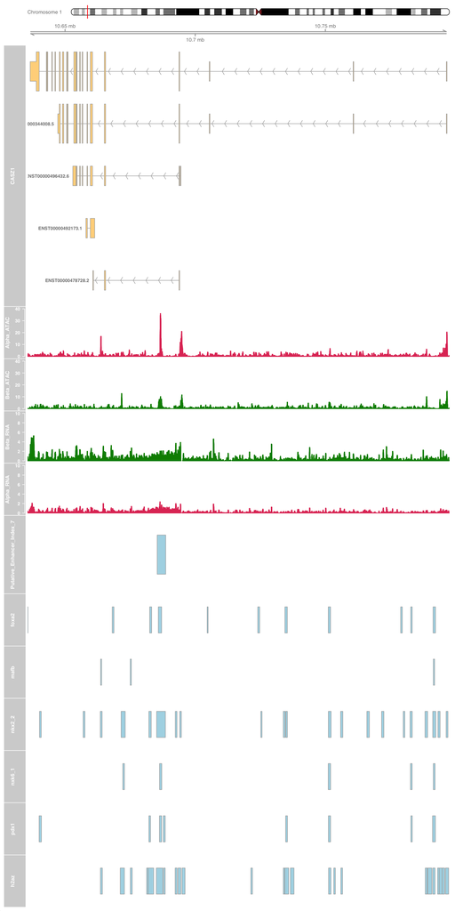

```r
## What about a region that overlapped with super enhancers from the
## human islet regulome database?

epiRomics_putative_enhanceosome_regulome_super <- epiRomics_enhanceosome(epiRomics_putative_enhancers_filtered_regulome_super,
    epiRomics_dB)
```

```
#> >> preparing features information...      2021-09-28 19:13:34
#> >> identifying nearest features...        2021-09-28 19:13:34
#> >> calculating distance from peak to TSS...   2021-09-28 19:13:34
#> >> assigning genomic annotation...        2021-09-28 19:13:34
#> >> adding gene annotation...          2021-09-28 19:13:42
#> >> assigning chromosome lengths           2021-09-28 19:13:42
#> >> done...                    2021-09-28 19:13:42
```

```r
epiRomics_putative_enhanceosome_regulome_super@annotations
```

```
#> GRanges object with 2401 ranges and 19 metadata columns:
#>        seqnames              ranges strand |     foxa2      mafb    nkx2_2
#>           <Rle>           <IRanges>  <Rle> | <integer> <integer> <integer>
#>    166     chr1 154418514-154419684      * |         2         2         1
#>    966     chr9     2242369-2242873      * |         2         1         1
#>   1422    chr11   65416576-65419753      * |         1         1         2
#>     16     chr1   10685395-10688670      * |         1         0         1
#>    764     chr6   30748438-30749427      * |         2         1         1
#>    ...      ...                 ...    ... .       ...       ...       ...
#>   2393    chr22   46103687-46105878      * |         0         0         0
#>   2396    chr22   46108912-46109315      * |         0         0         0
#>   2397    chr22   46109916-46110442      * |         0         0         0
#>   2398    chr22   46115774-46116154      * |         0         0         0
#>   2399    chr22   46116326-46116501      * |         0         0         0
#>           nxk6_1      pdx1      h2az ChIP_Hits             annotation   geneChr
```

[output cut: 41 more lines]

```r
head(as.data.frame(epiRomics_putative_enhanceosome_regulome_super@annotations)[as.data.frame(epiRomics_putative_enhanceosome_regulome_super@annotations)$seqnames ==
    "chr1", ])
```

|  | seqnames | start | end | width | strand | foxa2 | mafb | nkx2_2 | nxk6_1 | pdx1 | h2az | ChIP_Hits | annotation | geneChr | geneStart | geneEnd | geneLength | geneStrand | geneId | transcriptId | distanceToTSS | ENSEMBL | SYMBOL | GENENAME |
| --- | --- | --- | --- | --- | --- | --- | --- | --- | --- | --- | --- | --- | --- | --- | --- | --- | --- | --- | --- | --- | --- | --- | --- | --- |
| 166 | chr1 | 154418514 | 154419684 | 1171 | * | 2 | 2 | 1 | 2 | 1 | 2 | 10 | Intron (ENST00000622330.4/3570, intron 1 of 6) | 1 | 154429343 | 154449979 | 20637 | 1 | 3570 | ENST00000476006.5 | -9659 | ENSG00000160712 | IL6R | interleukin 6 receptor |
| 16 | chr1 | 10685395 | 10688670 | 3276 | * | 1 | 0 | 1 | 1 | 2 | 2 | 7 | Intron (ENST00000377022.8/54897, intron 4 of 20) | 1 | 10660737 | 10693912 | 33176 | 2 | 54897 | ENST00000478728.2 | 5242 | ENSG00000130940 | CASZ1 | castor zinc finger 1 |
| 1 | chr1 | 7574092 | 7574479 | 388 | * | 1 | 1 | 1 | 1 | 1 | 1 | 6 | Intron (ENST00000303635.12/23261, intron 6 of 22) | 1 | 7736408 | 7767856 | 31449 | 1 | 23261 | ENST00000495233.5 | -161929 | ENSG00000171735 | CAMTA1 | calmodulin binding transcription activator 1 |
| 2 | chr1 | 7574640 | 7575094 | 455 | * | 1 | 1 | 1 | 1 | 1 | 1 | 6 | Intron (ENST00000303635.12/23261, intron 6 of 22) | 1 | 7736408 | 7767856 | 31449 | 1 | 23261 | ENST00000495233.5 | -161314 | ENSG00000171735 | CAMTA1 | calmodulin binding transcription activator 1 |
| 3 | chr1 | 8169274 | 8169689 | 416 | * | 1 | 1 | 1 | 1 | 1 | 1 | 6 | Distal Intergenic | 1 | 8201518 | 8215207 | 13690 | 1 | 102724539 | ENST00000670361.1 | -31829 | ENSG00000227634 | LINC01714 | long intergenic non-protein coding RNA 1714 |
| 4 | chr1 | 8170112 | 8170857 | 746 | * | 1 | 1 | 1 | 1 | 1 | 1 | 6 | Distal Intergenic | 1 | 8201518 | 8215207 | 13690 | 1 | 102724539 | ENST00000670361.1 | -30661 | ENSG00000227634 | LINC01714 | long intergenic non-protein coding RNA 1714 |

```r
## Find Index
which(names(epiRomics_putative_enhanceosome_regulome_super@annotations) ==
    1)
```

```
#> [1] 14
```

```r
epiRomics_track_layer_human(
  epiRomics_putative_enhanceosome_regulome_super,
  epiRomics_index = which(
    names(epiRomics_putative_enhanceosome_regulome_super@annotations) == 1
  ),
  epiRomics_dB = epiRomics_dB,
  epiRomics_track_connection = epiRomics_track_connection
)
```

```
#> [1] "not empty"
#> [1] 243.743
#> [1] "not empty"
#> [1] 103.706
#> [1] "not empty"
#> [1] 11.3213
#> [1] "not empty"
#> [1] 22.1498
```

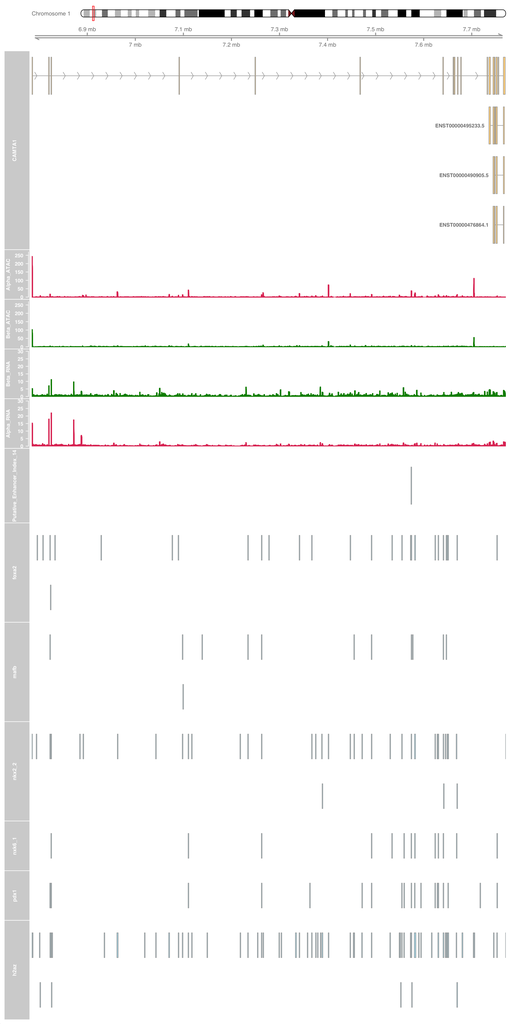

```r
## Or, about a region that overlapped with ultra-conserved non coding
## elements?

epiRomics_putative_enhanceosome_ucnes <- epiRomics_enhanceosome(epiRomics_putative_enhancers_filtered_ucnes,
    epiRomics_dB)
```

```
#> >> preparing features information...      2021-09-28 19:15:36
#> >> identifying nearest features...        2021-09-28 19:15:36
#> >> calculating distance from peak to TSS...   2021-09-28 19:15:37
#> >> assigning genomic annotation...        2021-09-28 19:15:37
#> >> adding gene annotation...          2021-09-28 19:15:44
#> >> assigning chromosome lengths           2021-09-28 19:15:44
#> >> done...                    2021-09-28 19:15:44
```

```r
epiRomics_putative_enhanceosome_ucnes@annotations
```

```
#> GRanges object with 11 ranges and 19 metadata columns:
#>      seqnames              ranges strand |     foxa2      mafb    nkx2_2
#>         <Rle>           <IRanges>  <Rle> | <integer> <integer> <integer>
#>    7     chr9 106921420-106921764      * |         1         1         1
#>    1     chr1 164635220-164635921      * |         0         0         2
#>    6     chr3   71131859-71132164      * |         1         0         0
#>    2     chr1 164711914-164712296      * |         0         0         0
#>    3     chr1 164712350-164713071      * |         0         0         0
#>    8    chr11 114163425-114164860      * |         0         0         0
#>    9    chr15   36903894-36904085      * |         0         0         1
#>   11    chr21   16534340-16534665      * |         0         0         0
#>    4     chr1 200079185-200079426      * |         0         0         0
#>    5     chr1 213585694-213586385      * |         0         0         0
#>   10    chr15   53447393-53447809      * |         0         0         0
#>         nxk6_1      pdx1      h2az ChIP_Hits             annotation   geneChr
```

[output cut: 40 more lines]

```r
epiRomics_track_layer_human(
  epiRomics_putative_enhanceosome_ucnes,
  epiRomics_index = 9,
  epiRomics_dB = epiRomics_dB,
  epiRomics_track_connection = epiRomics_track_connection
)
```

```
#> [1] "not empty"
#> [1] 82.795
#> [1] "not empty"
#> [1] 62.847
#> [1] "not empty"
#> [1] 3.55117
#> [1] "not empty"
#> [1] 3.80884
```

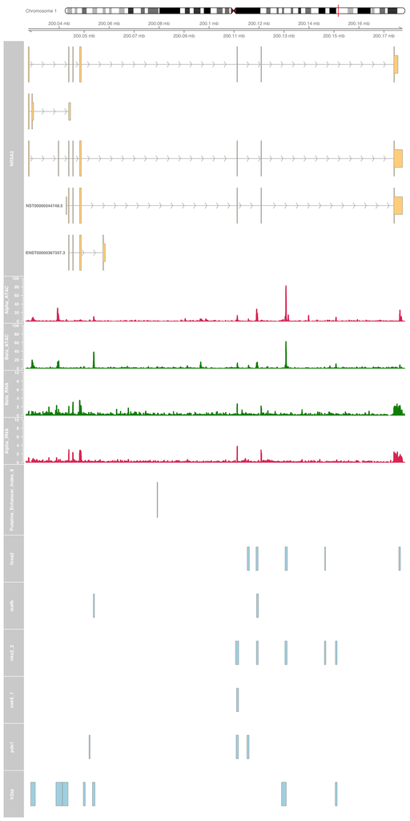

```r
## How about applying multiple filters to further increase the confidence of calls?

epiRomics_putative_enhancers_filtered_stringent <-
  epiRomics_enhancers_filter(
    epiRomics_enhancers_filter(
      epiRomics_enhancers_filter(
        epiRomics_enhancers_filter(epiRomics_putative_enhancers, epiRomics_dB,
          epiRomics_type =
            "hg38_custom_fantom"
        ),
        epiRomics_dB,
        epiRomics_type = "hg38_custom_regulome_active"
      ),
      epiRomics_dB,
      epiRomics_type = "hg38_custom_regulome_super"
    ),
    epiRomics_dB,
    epiRomics_type = "hg38_custom_ucnes"
  )


## Here, we see a highly conservative list of putative enhancer calls that overlap with four different functional annotations, suggesting the lowest hanging fruit for downstream bench-lab validation. NOTE: The UCNE database filter caused the greatest reduction in enhancer calls.
epiRomics_putative_enhancers_filtered_stringent@annotations
```

```
#> GRanges object with 2 ranges and 0 metadata columns:
#>       seqnames              ranges strand
#>          <Rle>           <IRanges>  <Rle>
#>   [1]     chr1 164711914-164712296      *
#>   [2]     chr1 164712350-164713071      *
#>   -------
#>   seqinfo: 595 sequences (1 circular) from hg38 genome
```

```r
epiRomics_putative_enhanceosome_stringent <-
  epiRomics_enhanceosome(
    epiRomics_putative_enhancers_filtered_stringent,
    epiRomics_dB
  )
```

```
#> >> preparing features information...      2021-09-28 19:18:08
#> >> identifying nearest features...        2021-09-28 19:18:08
#> >> calculating distance from peak to TSS...   2021-09-28 19:18:10
#> >> assigning genomic annotation...        2021-09-28 19:18:10
#> >> adding gene annotation...          2021-09-28 19:18:17
#> >> assigning chromosome lengths           2021-09-28 19:18:17
#> >> done...                    2021-09-28 19:18:17
```

```r
epiRomics_track_layer_human(
  epiRomics_putative_enhanceosome_stringent,
  epiRomics_index = 1,
  epiRomics_dB = epiRomics_dB,
  epiRomics_track_connection = epiRomics_track_connection
)
```

```
#> [1] "not empty"
#> [1] 233.705
#> [1] "not empty"
#> [1] 221.083
#> [1] "not empty"
#> [1] 9.31751
#> [1] "not empty"
#> [1] 15.8259
```

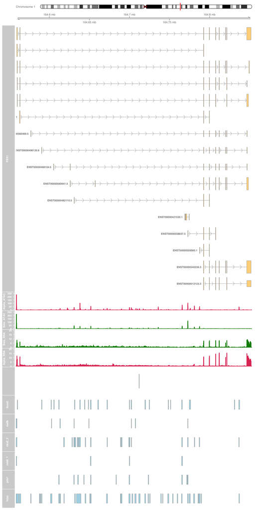

```r
## How can we use these putative enhanceosome regions to infer
## biology between cell states? In this example, we will integrate
## ATAC-Seq data differential testing showing differences in
## chromatin accessibility between alpha and beta cells

## Read differentially binding data generated with DiffBind comparing
## human alpha and beta cell chromatin
b.v.a <- read.csv(system.file("extdata", "DBA_Beta_Versus_Alpha.csv", package = "epiRomics"))
b.v.a <- GRanges(b.v.a)

# Filter for beta enriched chromatin regions
beta.enriched <- b.v.a[b.v.a$Fold >= 1, ]

# Connect to our putative enhanceosomes
beta_enhancer_regions <- epiRomics_regions_of_interest(epiRomics_putative_enhanceosome_fantom,
    beta.enriched)
```

```r
## Now, lets visualize the top candidate region we found after connecting our differential chromatin analysis with the putative enhanceosomes
epiRomics_track_layer_human(
  beta_enhancer_regions,
  epiRomics_index = 1,
  epiRomics_dB = epiRomics_dB,
  epiRomics_track_connection = epiRomics_track_connection
)
```

```
#> [1] "not empty"
#> [1] 16.5139
#> [1] "not empty"
#> [1] 14.2229
#> [1] "not empty"
#> [1] 2.38379
#> [1] "not empty"
#> [1] 1.29041
```

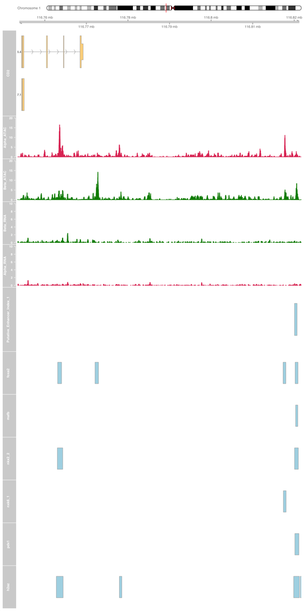